# Anàlisi de l’índex de pobresa temporal Catalunya · 2024

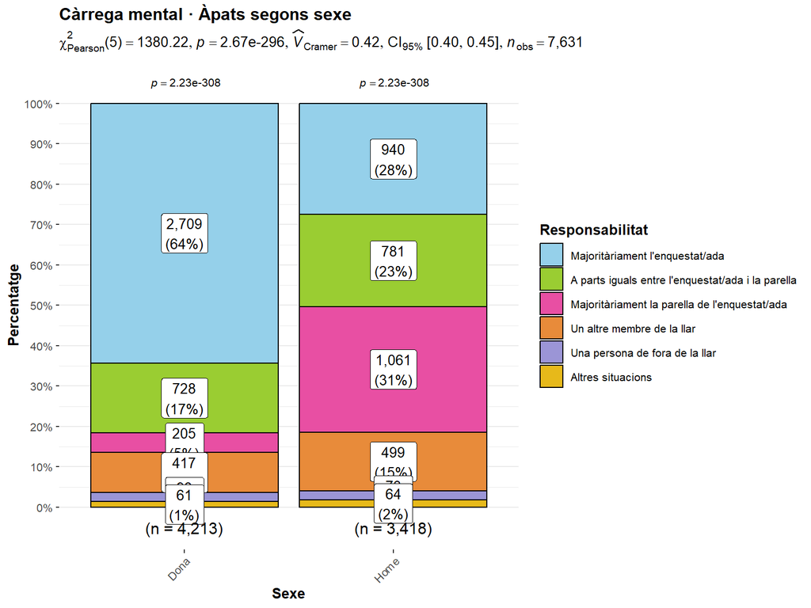

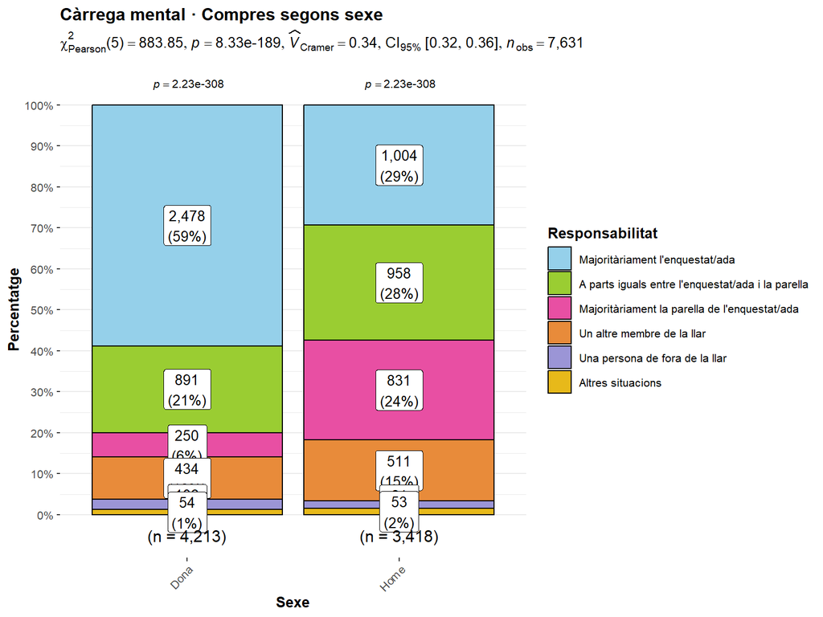

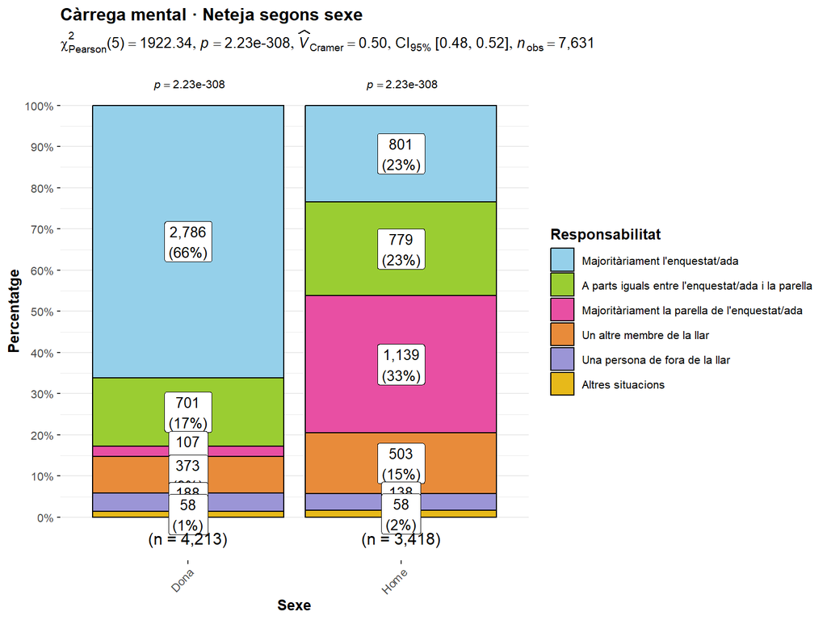

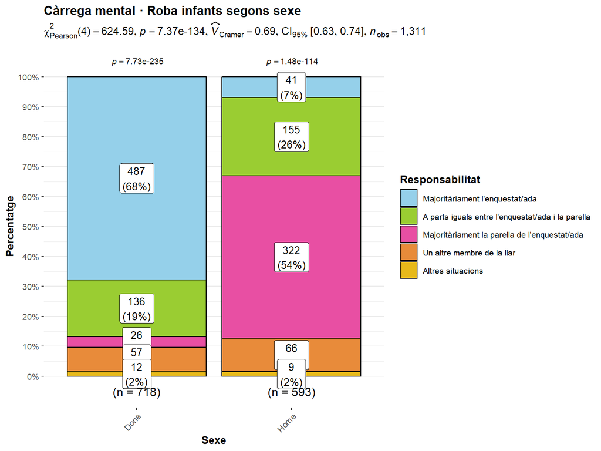

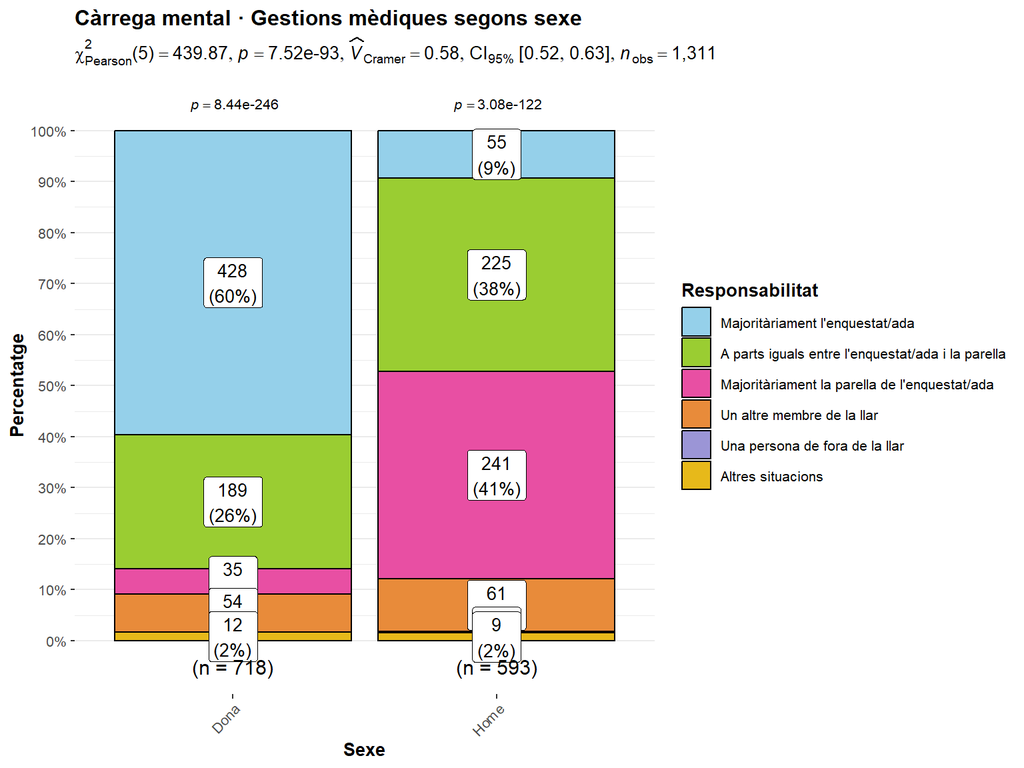

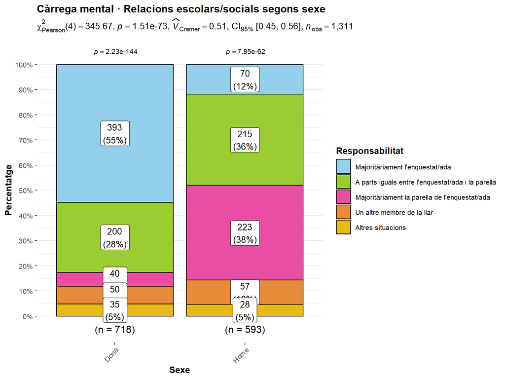

```r
walk(levels(dades_mentals_2024$tasca),
     ~ print(plot_chi_carrega(dades_mentals_2024, "SEXE", .x, "Sexe")))
```

### 4.7.2 3.7.2 Segons nacionalitat

```r
knitr::kable(resum_chi_carrega(dades_mentals_2024, "NAC"),
             caption = "Test χ² d'independència i V de Cramér: tasca × nacionalitat")
```

Test χ² d’independència i V de Cramér: tasca × nacionalitat

| Tasca | N | χ² | gl | p-valor | V de Cramér |
| --- | --- | --- | --- | --- | --- |
| Àpats | 7631 | 25.93 | 5 | p < 0.01 | 0.058 |
| Compres | 7631 | 17.14 | 5 | p < 0.01 | 0.047 |
| Neteja | 7631 | 31.46 | 5 | p < 0.01 | 0.064 |
| Roba infants | 1311 | 6.94 | 4 | p = 0.139 | 0.073 |
| Gestions mèdiques | 1311 | 10.27 | 5 | p = 0.068 | 0.089 |
| Relacions escolars/socials | 1311 | 7.73 | 4 | p = 0.102 | 0.077 |

```r
datatable(taula_carrega(dades_mentals_2024, "NAC"), rownames = FALSE,
          caption = "Percentatge de respostes per nacionalitat i tasca",
          options = list(pageLength = 12))
```

| Grup | Tasca | Majoritàriament l'enquestat/ada | A parts iguals entre l'enquestat/ada i la parella | Majoritàriament la parella de l'enquestat/ada | Un altre membre de la llar | Una persona de fora de la llar | Altres situacions |
| --- | --- | --- | --- | --- | --- | --- | --- |
| Espanyola | Àpats | 48.1 | 19.3 | 16.7 | 12 | 2.4 | 1.5 |
| Espanyola | Compres | 45.8 | 23.9 | 14.3 | 12.2 | 2.4 | 1.3 |
| Espanyola | Neteja | 47.2 | 19 | 16.4 | 11.2 | 4.7 | 1.5 |
| Espanyola | Roba infants | 40.1 | 22 | 27.6 | 8.4 | 0 | 1.9 |
| Espanyola | Gestions mèdiques | 36.2 | 32.5 | 21.4 | 7.7 | 0.2 | 2 |
| Espanyola | Relacions escolars/socials | 34.6 | 33 | 20.1 | 7.2 | 0 | 5.1 |
| Estrangera | Àpats | 46.1 | 23.1 | 15.5 | 12 | 0.6 | 2.6 |
| Estrangera | Compres | 44.5 | 26.3 | 13.1 | 13.4 | 0.7 | 2 |
| Estrangera | Neteja | 45.6 | 21.9 | 16 | 13.2 | 1.3 | 2 |
| Estrangera | Roba infants | 40.8 | 22.7 | 23.6 | 12.1 | 0 | 0.9 |

[output cut: 2 more lines]

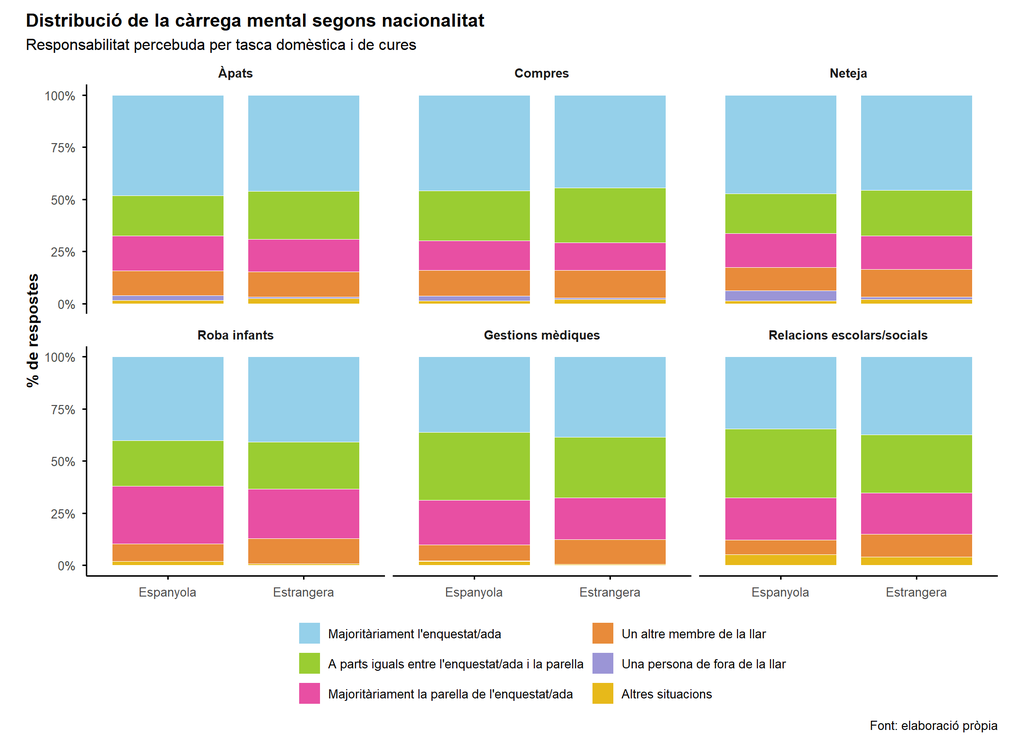

```r
mostra(plot_carrega(dades_mentals_2024, "NAC", "Distribució de la càrrega mental segons nacionalitat"),
       "carrega_nac", 11, 8)
```

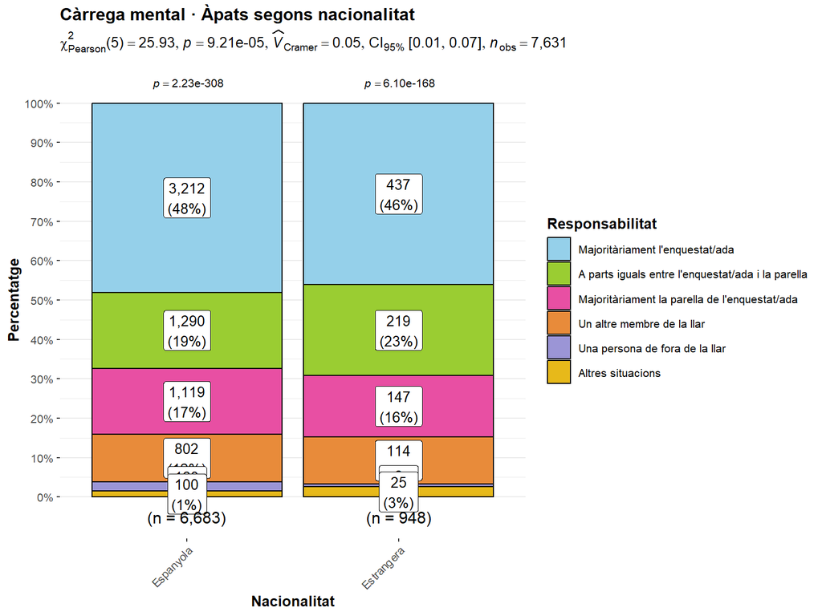

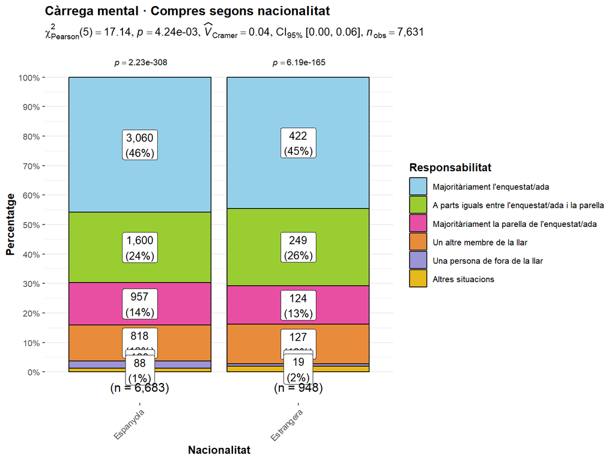

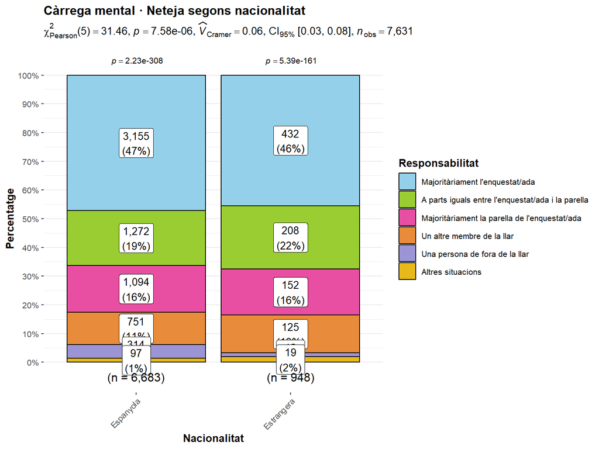

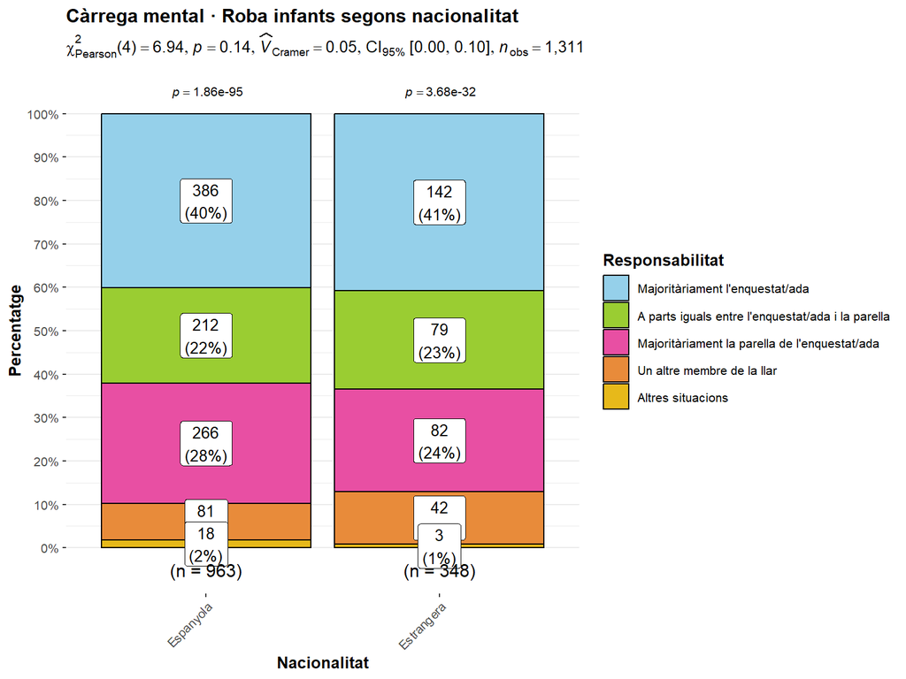

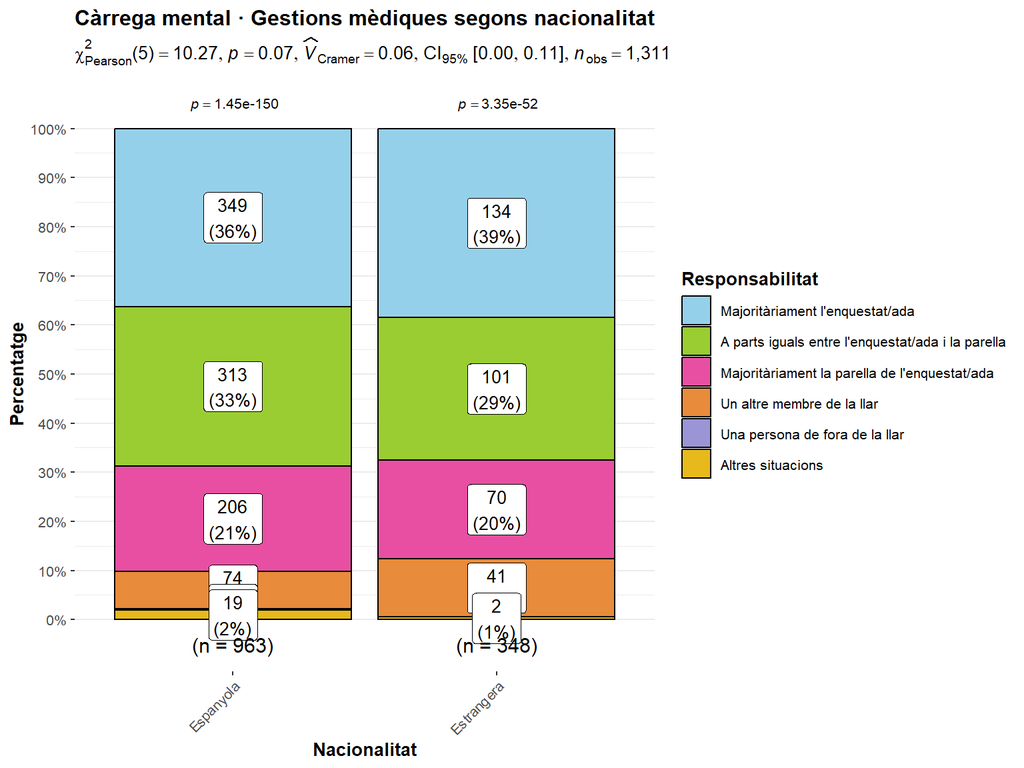

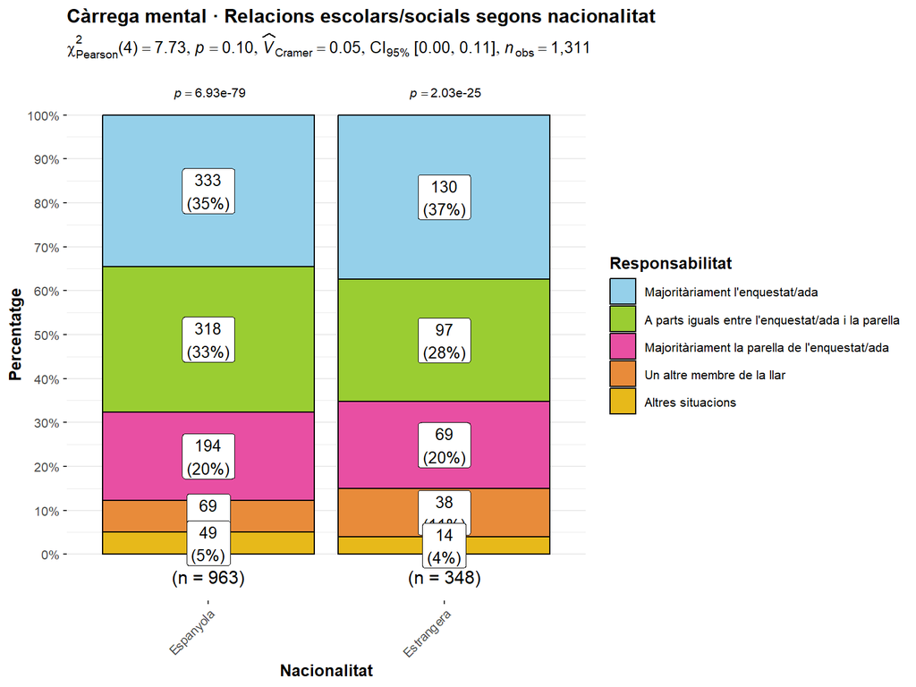

```r
walk(levels(dades_mentals_2024$tasca),
     ~ print(plot_chi_carrega(dades_mentals_2024, "NAC", .x, "Nacionalitat")))
```

### 4.7.3 3.7.3 Interseccional: sexe × nacionalitat

```r
knitr::kable(resum_chi_carrega(dades_mentals_2024, "sexe_nac"),
             caption = "Test χ² d'independència i V de Cramér: tasca × sexe i nacionalitat")
```

Test χ² d’independència i V de Cramér: tasca × sexe i nacionalitat

| Tasca | N | χ² | gl | p-valor | V de Cramér |
| --- | --- | --- | --- | --- | --- |
| Àpats | 7631 | 1416.36 | 15 | p < 0.01 | 0.249 |
| Compres | 7631 | 920.30 | 15 | p < 0.01 | 0.200 |
| Neteja | 7631 | 1971.17 | 15 | p < 0.01 | 0.293 |
| Roba infants | 1311 | 637.11 | 12 | p < 0.01 | 0.402 |
| Gestions mèdiques | 1311 | 466.36 | 15 | p < 0.01 | 0.344 |
| Relacions escolars/socials | 1311 | 376.32 | 12 | p < 0.01 | 0.309 |

```r
datatable(taula_carrega(dades_mentals_2024, "sexe_nac"), rownames = FALSE,
          caption = "Percentatge de respostes per sexe × nacionalitat i tasca",
          options = list(pageLength = 12))
```

| Grup | Tasca | Majoritàriament l'enquestat/ada | A parts iguals entre l'enquestat/ada i la parella | Majoritàriament la parella de l'enquestat/ada | Un altre membre de la llar | Una persona de fora de la llar | Altres situacions |
| --- | --- | --- | --- | --- | --- | --- | --- |
| Dones espanyoles | Àpats | 64.8 | 16.7 | 4.7 | 9.9 | 2.4 | 1.4 |
| Dones espanyoles | Compres | 59.3 | 20.8 | 5.6 | 10.1 | 2.8 | 1.3 |
| Dones espanyoles | Neteja | 66.6 | 16.2 | 2.3 | 8.5 | 5 | 1.5 |
| Dones espanyoles | Roba infants | 68.2 | 18.4 | 3.5 | 8 | 0 | 1.9 |
| Dones espanyoles | Gestions mèdiques | 61.4 | 26 | 3.1 | 7.4 | 0 | 2.1 |
| Dones espanyoles | Relacions escolars/socials | 56.7 | 27.6 | 3.3 | 6.8 | 0 | 5.6 |
| Dones estrangeres | Àpats | 60.6 | 21.1 | 6.2 | 9.7 | 0.7 | 1.6 |
| Dones estrangeres | Compres | 55.3 | 23.8 | 7.9 | 11.4 | 0.7 | 0.9 |
| Dones estrangeres | Neteja | 63.2 | 19.8 | 3.8 | 11.5 | 0.9 | 0.7 |
| Dones estrangeres | Roba infants | 67 | 20.2 | 3.9 | 7.9 | 0 | 1 |

[output cut: 14 more lines]

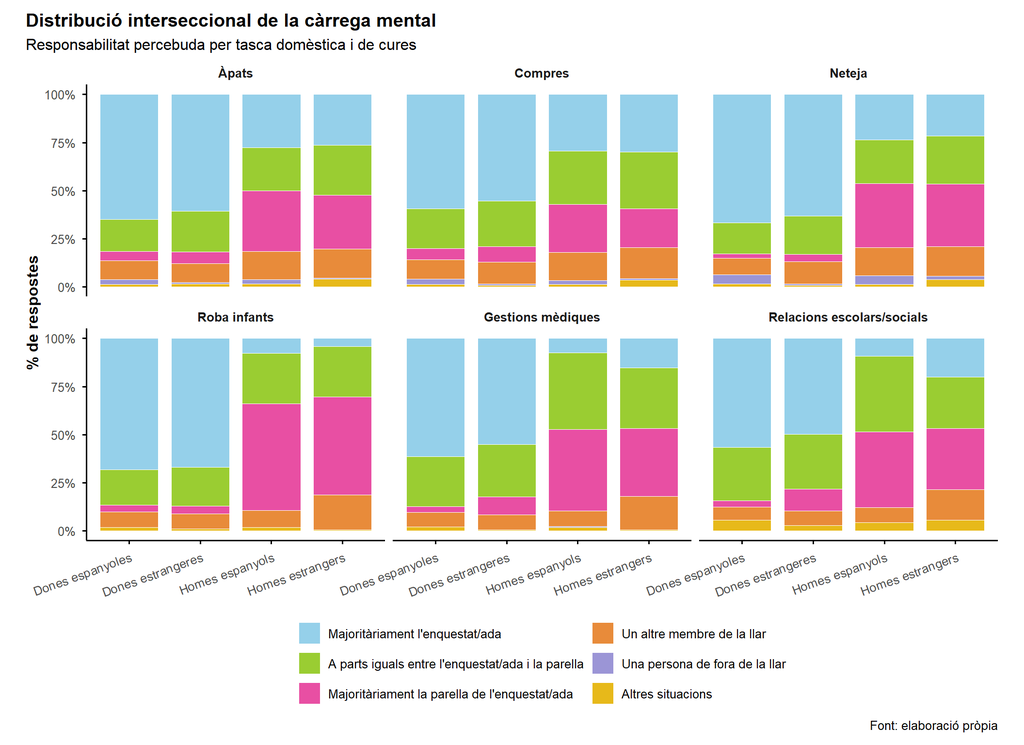

```r
mostra(plot_carrega(dades_mentals_2024, "sexe_nac",
                    "Distribució interseccional de la càrrega mental", angle = 20),
       "carrega_interseccional", 11, 8)
```

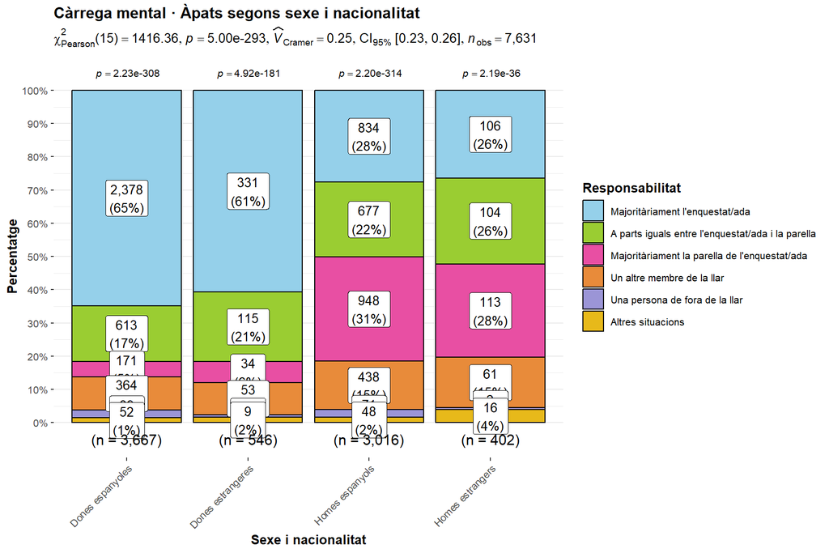

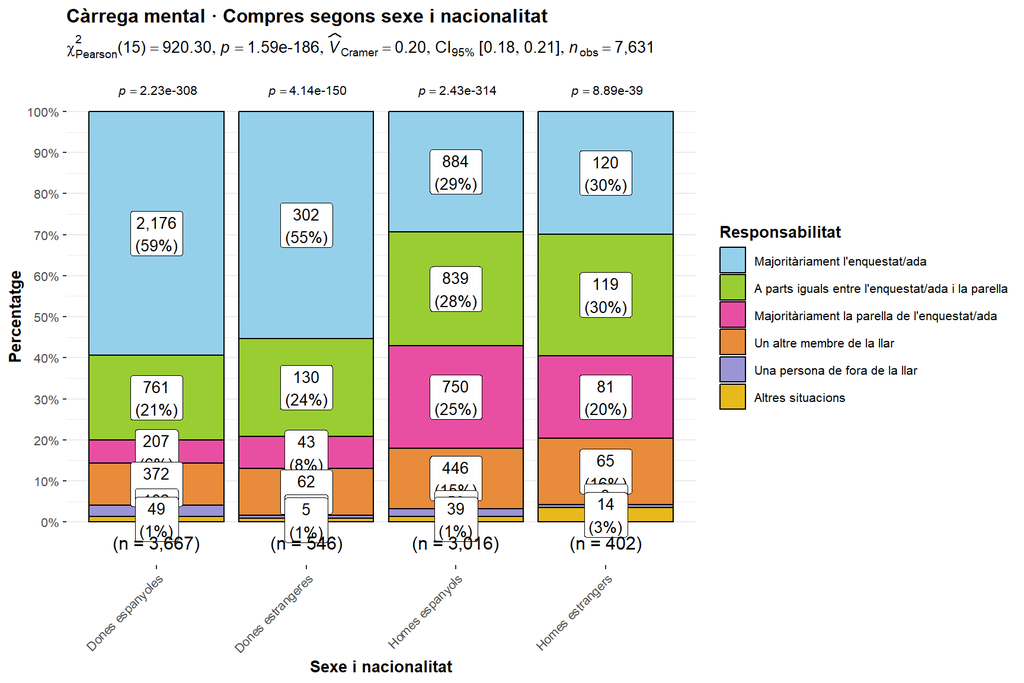

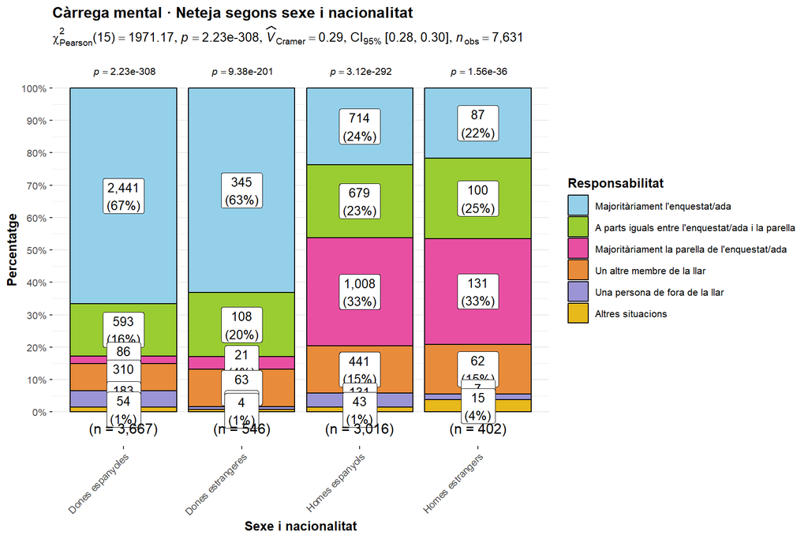

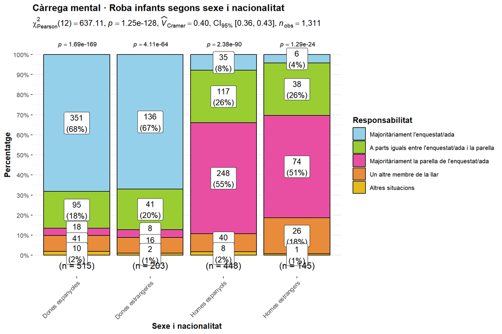

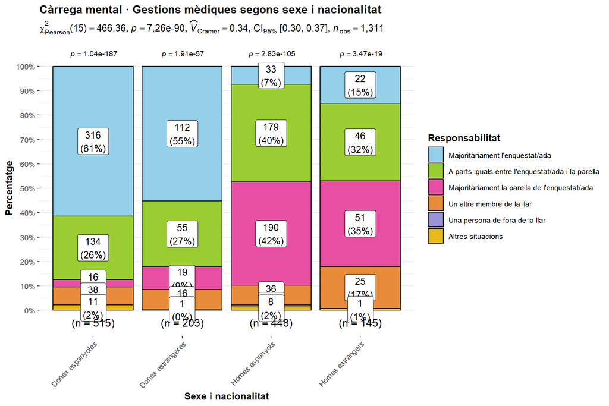

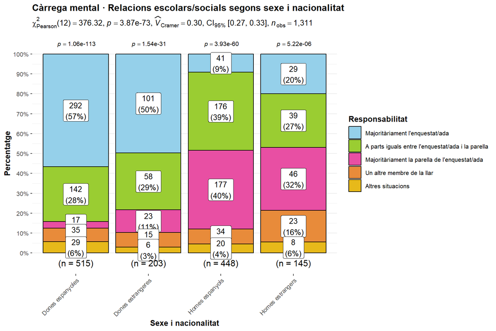

```r
walk(levels(dades_mentals_2024$tasca),
     ~ print(plot_chi_carrega(dades_mentals_2024, "sexe_nac", .x, "Sexe i nacionalitat")))
```

# 5 4 Modelització

## 5.1 4.1 Models logit amb efectes aleatoris

$$\text{logit}(P(Y=1)) = \log\left(\frac{P(Y=1)}{1-P(Y=1)}\right)
= \beta_0 + \beta_1 X_1 + \beta_2 X_2 + \cdots + u_j$$

on $Y = 1$ indica pobresa temporal, $u_j$ és l’intercept aleatori de la llar $j$ i els $\beta$ són coeficients en log-odds (l’*odds ratio* és $e^{\beta}$).

## 5.2 4.2 Ajust i selecció de models

```r
mod0 <- glm(
  IPT ~ SEXE + TRAM_EDAT + AD_DEP + DEGURBA + TIPUS_LLAR + TIPUS_DIA +
    NAC + ESTAT_CIVIL + ESTUDI_ALT + LIMITACIONS + NUM_MEMBRES + AJ_TOTAL +
    VOL_TOTAL + REL_ACT + MALALTIA_LLARGA,
  data = dades_models_2024, family = binomial(link = "logit"))

mod1 <- glmmTMB(
  IPT ~ SEXE + TRAM_EDAT + AD_DEP + DEGURBA + TIPUS_LLAR + TIPUS_DIA +
    NAC + ESTAT_CIVIL + ESTUDI_ALT + NUM_MEMBRES + AJ_TOTAL +
    VOL_TOTAL + REL_ACT + MALALTIA_LLARGA + LIMITACIONS + (1 | IDLLAR),
  data = dades_models_2024, family = binomial(link = "logit"))

mod2 <- glmmTMB(
  IPT ~ SEXE + TRAM_EDAT + AD_DEP + DEGURBA + TIPUS_LLAR + TIPUS_DIA +
    NAC + ESTUDI_ALT + AJ_TOTAL + VOL_TOTAL + REL_ACT + (1 | IDLLAR),
  data = dades_models_2024, family = binomial(link = "logit"))

mod3 <- glmmTMB(
  IPT ~ SEXE + TRAM_EDAT + DEGURBA + TIPUS_LLAR + TIPUS_DIA + NAC + ESTUDI_ALT +
    VOL_TOTAL + REL_ACT + (1 | IDLLAR),
  data = dades_models_2024, family = binomial(link = "logit"))

mod4 <- glmmTMB(
  IPT ~ SEXE + TRAM_EDAT + DEGURBA + TIPUS_LLAR + TIPUS_DIA + NAC + ESTUDI_ALT +
    REL_ACT + (1 | IDLLAR),
  data = dades_models_2024, family = binomial(link = "logit"))
```

Els models es comparen amb els criteris AIC i BIC, amb proves de raó de versemblança entre models niats (`mod1` ⊃ `mod2` ⊃ `mod3` ⊃ `mod4`) i amb el criteri teòric de les variables que es volen estudiar, encara que no siguin significatives.

```r
comparacio <- AIC(mod0, mod1, mod2, mod3, mod4) %>%
  rownames_to_column("Model") %>%
  left_join(BIC(mod0, mod1, mod2, mod3, mod4) %>% rownames_to_column("Model") %>% select(Model, BIC),
            by = "Model")

knitr::kable(comparacio, digits = 1, caption = "Comparació de models (AIC i BIC)")
```

Comparació de models (AIC i BIC)

| Model | df | AIC | BIC |
| --- | --- | --- | --- |
| mod0 | 31 | 6711.9 | 6927.6 |
| mod1 | 32 | 6584.5 | 6807.2 |
| mod2 | 25 | 6578.7 | 6752.6 |
| mod3 | 23 | 6575.8 | 6735.9 |
| mod4 | 22 | 6575.2 | 6728.3 |

```r
anova(mod1, mod2, mod3, mod4) %>%
  as.data.frame() %>%
  knitr::kable(digits = 3, caption = "Proves de raó de versemblança entre models niats")
```

Proves de raó de versemblança entre models niats

|  | Df | AIC | BIC | logLik | deviance | Chisq | Chi Df | Pr(>Chisq) |
| --- | --- | --- | --- | --- | --- | --- | --- | --- |
| mod4 | 22 | 6575.231 | 6728.339 | -3265.616 | 6531.231 | NA | NA | NA |
| mod3 | 23 | 6575.820 | 6735.887 | -3264.910 | 6529.820 | 1.411 | 1 | 0.235 |
| mod2 | 25 | 6578.661 | 6752.647 | -3264.331 | 6528.661 | 1.158 | 2 | 0.560 |
| mod1 | 32 | 6584.463 | 6807.165 | -3260.231 | 6520.463 | 8.199 | 7 | 0.315 |

```r
mod_final <- mod4
```

## 5.3 4.3 Model final

### 5.3.1 4.3.1 Efectes fixos

```r
summary(mod_final)
```

```
##  Family: binomial  ( logit )
## Formula:
## IPT ~ SEXE + TRAM_EDAT + DEGURBA + TIPUS_LLAR + TIPUS_DIA + NAC +
##     ESTUDI_ALT + REL_ACT + (1 | IDLLAR)
## Data: dades_models_2024
##
##       AIC       BIC    logLik -2*log(L)  df.resid
##    6575.2    6728.3   -3265.6    6531.2      7759
##
## Random effects:
##
## Conditional model:
##  Groups Name        Variance Std.Dev.
##  IDLLAR (Intercept) 2.15     1.466
## Number of obs: 7781, groups:  IDLLAR, 4993
##
## Conditional model:
##                                  Estimate Std. Error z value Pr(>|z|)
## (Intercept)                      -0.85436    0.22874  -3.735 0.000188 ***
## SEXEHome                         -0.32956    0.07852  -4.197 2.70e-05 ***
## TRAM_EDAT25-44                    0.52169    0.17702   2.947 0.003209 **
## TRAM_EDAT45-64                    0.23965    0.16879   1.420 0.155655
## TRAM_EDAT65+                     -0.44310    0.27156  -1.632 0.102749
## DEGURBASemiurbà                   0.18372    0.10130   1.814 0.069739 .
## DEGURBARural                      0.36758    0.13875   2.649 0.008067 **
## TIPUS_LLARUnipersonal            -1.06888    0.14429  -7.408 1.28e-13 ***
## TIPUS_LLARParella sense fills    -0.87260    0.13341  -6.541 6.12e-11 ***
## TIPUS_LLARMonoparental fills <25  0.06864    0.17304   0.397 0.691614
## TIPUS_LLARMonoparental fills ≥25 -0.76496    0.22958  -3.332 0.000862 ***
## TIPUS_LLARParella amb fills ≥25  -0.61432    0.19762  -3.109 0.001880 **
## TIPUS_LLARAltres                 -0.42373    0.16266  -2.605 0.009188 **
## TIPUS_DIADia inusual             -1.13103    0.11120 -10.171  < 2e-16 ***
## NACEstrangera                     0.37939    0.12147   3.123 0.001788 **
## ESTUDI_ALTSecundaria 1a etapa     0.24228    0.16089   1.506 0.132085
## ESTUDI_ALTSecundaria 2a etapa     0.31281    0.13857   2.257 0.023984 *
## ESTUDI_ALTSuperior                0.01444    0.13223   0.109 0.913025
## REL_ACTAturat                    -1.75034    0.17077 -10.250  < 2e-16 ***
## REL_ACTJubilat                   -2.28654    0.25463  -8.980  < 2e-16 ***
## REL_ACTInactiu                   -1.47824    0.14589 -10.133  < 2e-16 ***
## ---
## Signif. codes:  0 '***' 0.001 '**' 0.01 '*' 0.05 '.' 0.1 ' ' 1
```

*Odds ratios* i intervals de confiança al 95%:

```r
taula_or <- broom.mixed::tidy(mod_final, effects = "fixed", conf.int = TRUE, exponentiate = TRUE) %>%
  transmute(Variable = term, OR = estimate,
            `IC 95% inf.` = conf.low, `IC 95% sup.` = conf.high, `p-valor` = p.value) %>%
  mutate(across(where(is.numeric), ~ round(.x, 3)))

datatable(taula_or, rownames = FALSE, options = list(pageLength = 15)) %>%
  formatStyle("p-valor", fontWeight = styleInterval(0.05, c("bold", "normal")))
```

| Variable | OR | IC 95% inf. | IC 95% sup. | p-valor |
| --- | --- | --- | --- | --- |
| (Intercept) | 0.426 | 0.272 | 0.666 | 0 |
| SEXEHome | 0.719 | 0.617 | 0.839 | 0 |
| TRAM_EDAT25-44 | 1.685 | 1.191 | 2.384 | 0.003 |
| TRAM_EDAT45-64 | 1.271 | 0.913 | 1.769 | 0.156 |
| TRAM_EDAT65+ | 0.642 | 0.377 | 1.093 | 0.103 |
| DEGURBASemiurbà | 1.202 | 0.985 | 1.466 | 0.07 |
| DEGURBARural | 1.444 | 1.1 | 1.896 | 0.008 |
| TIPUS_LLARUnipersonal | 0.343 | 0.259 | 0.456 | 0 |
| TIPUS_LLARParella sense fills | 0.418 | 0.322 | 0.543 | 0 |
| TIPUS_LLARMonoparental fills &lt;25 | 1.071 | 0.763 | 1.503 | 0.692 |

[output cut: 11 more lines]

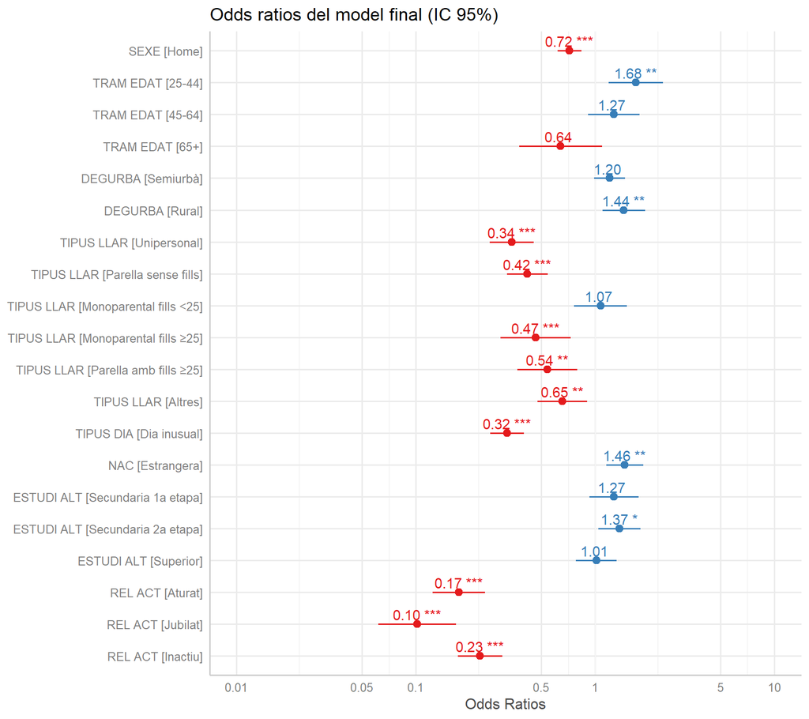

```r
plot_model(mod_final, transform = "exp", show.values = TRUE, value.offset = 0.3,
           title = "Odds ratios del model final (IC 95%)") +
  theme_sjplot()
```

### 5.3.2 4.3.2 Efectes aleatoris

```r
VarCorr(mod_final)
```

```
##
## Conditional model:
##  Groups Name        Std.Dev.
##  IDLLAR (Intercept) 1.4663
```

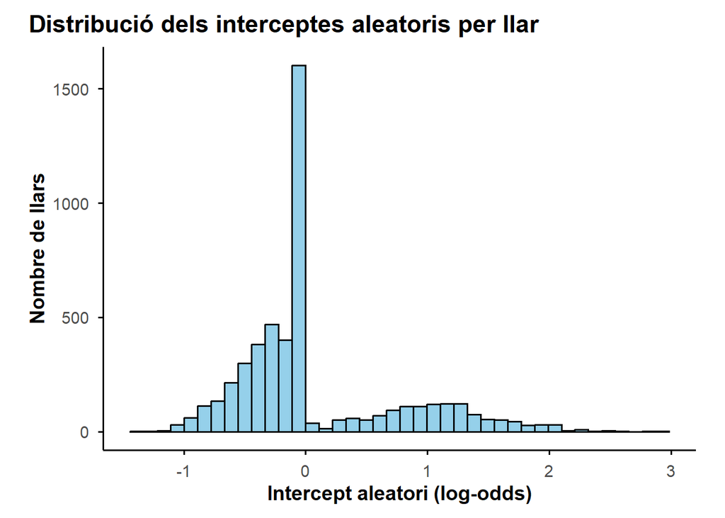

```r
sigma_re <- unname(attr(VarCorr(mod_final)$cond$IDLLAR, "stddev"))

ranef(mod_final)$cond$IDLLAR %>%
  as.data.frame() %>%
  ggplot(aes(x = `(Intercept)`)) +
  geom_histogram(bins = 40, fill = "#95D0EA", color = "black") +
  labs(title = "Distribució dels interceptes aleatoris per llar",
       x = "Intercept aleatori (log-odds)", y = "Nombre de llars") +
  tema_tfg()
```

La desviació estàndar de l’intercept aleatori és de σ = 1.466.

```r
icc_mod <- performance::icc(mod_final)
r2_mod <- performance::r2(mod_final)

tibble(
  Mesura = c("ICC ajustat", "ICC no ajustat", "R² marginal (Nakagawa)", "R² condicional (Nakagawa)"),
  Valor = round(c(icc_mod$ICC_adjusted, icc_mod$ICC_unadjusted,
                  unname(r2_mod$R2_marginal), unname(r2_mod$R2_conditional)), 3)
) %>%
  knitr::kable(caption = "Variabilitat entre llars i capacitat explicativa")
```

Variabilitat entre llars i capacitat explicativa

| Mesura | Valor |
| --- | --- |
| ICC ajustat | 0.395 |
| ICC no ajustat | 0.270 |
| R² marginal (Nakagawa) | 0.316 |
| R² condicional (Nakagawa) | 0.586 |

L’ICC no ajustat respon a quanta variació hi ha entre grups en general; l’ICC ajustat, a quanta en queda un cop explicada la part atribuïble a les covariables. Amb un ICC ajustat de 0.395, aproximadament el 39.5% de la variabilitat latent és atribuïble a diferències entre llars. L’R² marginal (0.316) indica la part explicada pels efectes fixos, i el condicional (0.586) la part explicada per fixos i aleatoris conjuntament.

### 5.3.3 4.3.3 Validació del model

```r
res_sim <- simulateResiduals(mod_final)
proves_res <- testResiduals(res_sim, plot = FALSE)

tibble(
  Test = c("Uniformitat (Kolmogorov-Smirnov)", "Dispersió", "Outliers"),
  `p-valor` = round(c(proves_res$uniformity$p.value,
                      proves_res$dispersion$p.value,
                      proves_res$outliers$p.value), 3)
) %>%
  knitr::kable(caption = "Tests sobre els residus simulats (DHARMa)")
```

Tests sobre els residus simulats (DHARMa)

| Test | p-valor |
| --- | --- |
| Uniformitat (Kolmogorov-Smirnov) | 0.000 |
| Dispersió | 0.000 |
| Outliers | 0.002 |

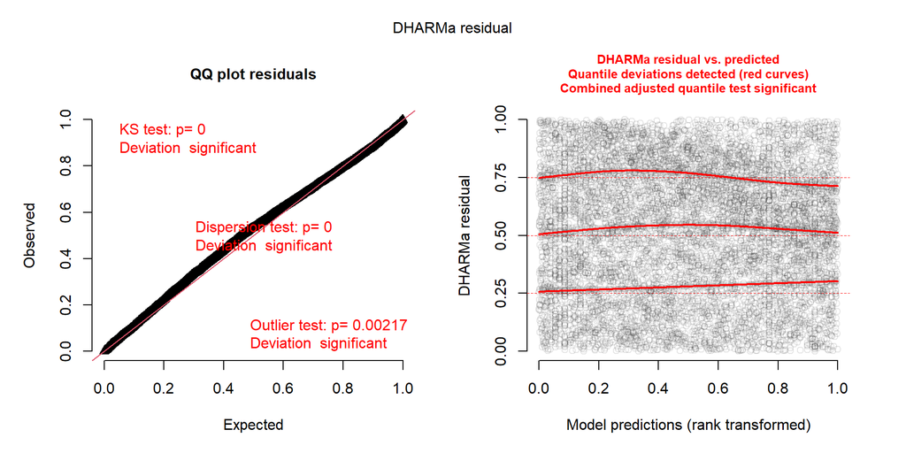

```r
plot(res_sim)
```

```r
check_collinearity(mod_final) %>%
  as.data.frame() %>%
  knitr::kable(digits = 2, caption = "Multicol·linealitat (VIF)")
```

Multicol·linealitat (VIF)

| Term | VIF | VIF_CI_low | VIF_CI_high | SE_factor | Tolerance | Tolerance_CI_low | Tolerance_CI_high |
| --- | --- | --- | --- | --- | --- | --- | --- |
| SEXE | 1.07 | 1.06 | 1.08 | 1.04 | 0.93 | 0.92 | 0.95 |
| TRAM_EDAT | 3.18 | 3.08 | 3.27 | 1.21 | 0.31 | 0.31 | 0.33 |
| DEGURBA | 1.05 | 1.04 | 1.06 | 1.01 | 0.95 | 0.94 | 0.96 |
| TIPUS_LLAR | 1.22 | 1.19 | 1.24 | 1.02 | 0.82 | 0.81 | 0.84 |
| TIPUS_DIA | 1.05 | 1.04 | 1.06 | 1.03 | 0.95 | 0.94 | 0.96 |
| NAC | 1.09 | 1.08 | 1.11 | 1.05 | 0.91 | 0.90 | 0.93 |
| ESTUDI_ALT | 1.25 | 1.22 | 1.27 | 1.04 | 0.80 | 0.79 | 0.82 |
| REL_ACT | 3.20 | 3.10 | 3.29 | 1.21 | 0.31 | 0.30 | 0.32 |

Un p-valor superior a 0.05 als tests de DHARMa indica que no hi ha desviacions significatives respecte als supòsits del model, i valors de VIF inferiors a 5 indiquen absència de problemes rellevants de col·linealitat.